# COVID-19_Nigeria

# **Introduction**

## Nigeria

#### Nigeria, country located on the western coast of Africa. Nigeria has a diverse geography, with climates ranging from arid to humid equatorial.The national capital is Abuja.Nigeria is bordered to the north by Niger, to the east by Chad and Cameroon, to the south by the Gulf of Guinea of the Atlantic Ocean, and to the west by Benin.

## Climate of Nigeria

#### Nigeria has a tropical climate with variable rainy and dry seasons, depending on location. It is hot and wet most of the year in the southeast but dry in the southwest and farther inland. A savanna climate, with marked wet and dry seasons, prevails in the north and west, while a steppe climate with little precipitation is found in the far north.

## COVID-19 Pandemic in Nigeria

#### The COVID-19 pandemic in Nigeria is part of the worldwide pandemic of coronavirus disease 2019 (COVID-19) caused by severe acute respiratory syndrome coronavirus 2 (SARS-CoV-2). The first confirmed case in Nigeria was announced on 27 February 2020, when an Italian national in Lagos tested positive for the virus.On 9 March 2020, a second case of the virus was reported in Ewekoro, Ogun State, a Nigerian citizen who came into contact with the Italian national.

#### The effect of the virus in Nigeria has become notable worldwide for being extremely understated, as there have been just under 255,000 confirmed cases in a country of 200 million+; however, there has been far less testing for the virus in Nigeria than other countries.Deaths however have been minimal (3,143). This has been credited to a warmer climate, far younger populations (fewer people in care homes), faster government responses, and, crucially, experience in dealing with recent epidemics, such as the Ebola virus, that most Western countries lacked.

## Location of Nigeria

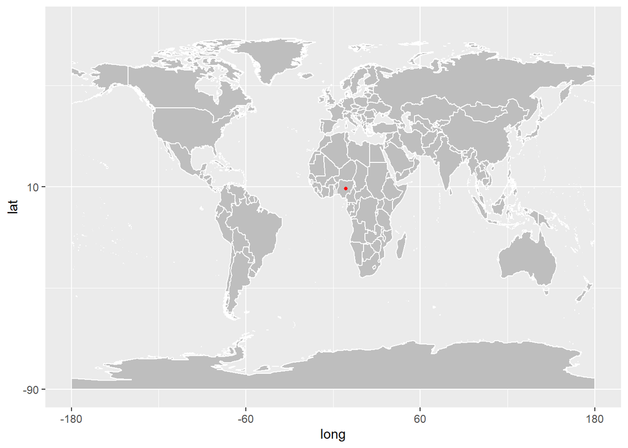

## **Exploratory Data Analysis**

#### Here is summary of the coronavirus dataframe in Nigeria.

### Summary of the covid-19 cases in Nigeria

```r
Nigeria_corona_new<-Nigeria_corona%>%mutate(cases=replace(cases,which(cases<0),NA))
 summary(Nigeria_corona_new)
```

```
      date              province           country               lat
 Min.   :2020-01-22   Length:2652        Length:2652        Min.   :9.082
 1st Qu.:2020-08-29   Class :character   Class :character   1st Qu.:9.082
 Median :2021-04-07   Mode  :character   Mode  :character   Median :9.082
 Mean   :2021-04-07                                         Mean   :9.082
 3rd Qu.:2021-11-14                                         3rd Qu.:9.082
 Max.   :2022-06-23                                         Max.   :9.082

      long           type               cases              uid
 Min.   :8.675   Length:2652        Min.   :    0.0   Min.   :566
 1st Qu.:8.675   Class :character   1st Qu.:    0.0   1st Qu.:566
 Median :8.675   Mode  :character   Median :    7.0   Median :566
 Mean   :8.675                      Mean   :  160.5   Mean   :566
 3rd Qu.:8.675                      3rd Qu.:  148.0   3rd Qu.:566
 Max.   :8.675                      Max.   :11188.0   Max.   :566
                                    NA's   :4
     iso2               iso3               code3     combined_key
 Length:2652        Length:2652        Min.   :566   Length:2652
 Class :character   Class :character   1st Qu.:566   Class :character
 Mode  :character   Mode  :character   Median :566   Mode  :character
                                       Mean   :566
                                       3rd Qu.:566
                                       Max.   :566

   population        continent_name     continent_code
 Min.   :206139587   Length:2652        Length:2652
 1st Qu.:206139587   Class :character   Class :character
 Median :206139587   Mode  :character   Mode  :character
 Mean   :206139587
 3rd Qu.:206139587
 Max.   :206139587
```

### summary of the confirmed cases

```
      date              province           country               lat
 Min.   :2020-01-22   Length:884         Length:884         Min.   :9.082
 1st Qu.:2020-08-29   Class :character   Class :character   1st Qu.:9.082
 Median :2021-04-07   Mode  :character   Mode  :character   Median :9.082
 Mean   :2021-04-07                                         Mean   :9.082
 3rd Qu.:2021-11-14                                         3rd Qu.:9.082
 Max.   :2022-06-23                                         Max.   :9.082

      long           type               cases             uid
 Min.   :8.675   Length:884         Min.   :   0.0   Min.   :566
 1st Qu.:8.675   Class :character   1st Qu.:  29.0   1st Qu.:566
 Median :8.675   Mode  :character   Median : 132.0   Median :566
 Mean   :8.675                      Mean   : 290.8   Mean   :566
 3rd Qu.:8.675                      3rd Qu.: 418.0   3rd Qu.:566
 Max.   :8.675                      Max.   :6158.0   Max.   :566
                                    NA's   :1
     iso2               iso3               code3     combined_key
 Length:884         Length:884         Min.   :566   Length:884
 Class :character   Class :character   1st Qu.:566   Class :character
 Mode  :character   Mode  :character   Median :566   Mode  :character
                                       Mean   :566
                                       3rd Qu.:566
                                       Max.   :566

   population        continent_name     continent_code
 Min.   :206139587   Length:884         Length:884
 1st Qu.:206139587   Class :character   Class :character
 Median :206139587   Mode  :character   Mode  :character
 Mean   :206139587
 3rd Qu.:206139587
 Max.   :206139587
```

### Imputing missing values

```r
which(is.na(confirmed_Nigeria_corona$cases))
```

```r
confirmed_Nigeria_corona$cases[813] = mean(c(confirmed_Nigeria_corona$cases[812],confirmed_Nigeria_corona$cases[814]))
length(confirmed_Nigeria_corona$cases)
```

```r
confirmed_Nigeria_corona$col <- as.factor(c(rep("black", 811),rep("red", 2), rep("black", 884-813)))
summary(confirmed_Nigeria_corona)
```

```
[1] 884
```

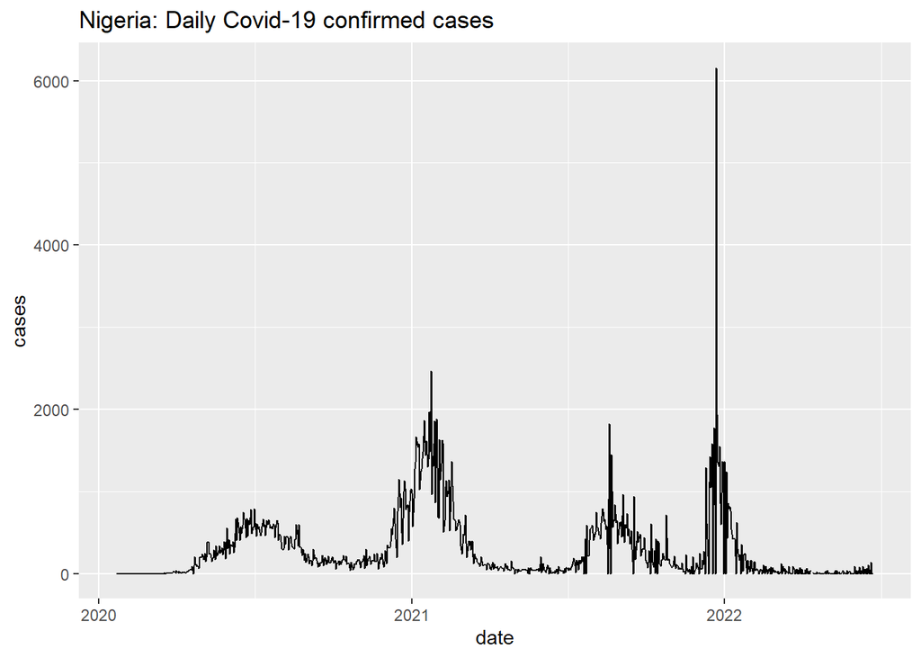

#### The highest number of Covid cases are confirmed at end of the year 2021.The middle part of the year 2020,the begining of the year 2021 and end of the year 2021 as well as very first begining of year 2022, there were some increasing in the confirmed corona cases.

### Summary of the Recovery Cases

```
      date              province           country               lat
 Min.   :2020-01-22   Length:884         Length:884         Min.   :9.082
 1st Qu.:2020-08-29   Class :character   Class :character   1st Qu.:9.082
 Median :2021-04-07   Mode  :character   Mode  :character   Median :9.082
 Mean   :2021-04-07                                         Mean   :9.082
 3rd Qu.:2021-11-14                                         3rd Qu.:9.082
 Max.   :2022-06-23                                         Max.   :9.082

      long           type               cases              uid
 Min.   :8.675   Length:884         Min.   :    0.0   Min.   :566
 1st Qu.:8.675   Class :character   1st Qu.:    0.0   1st Qu.:566
 Median :8.675   Mode  :character   Median :    8.0   Median :566
 Mean   :8.675                      Mean   :  187.1   Mean   :566
 3rd Qu.:8.675                      3rd Qu.:  178.5   3rd Qu.:566
 Max.   :8.675                      Max.   :11188.0   Max.   :566
                                    NA's   :1
     iso2               iso3               code3     combined_key
 Length:884         Length:884         Min.   :566   Length:884
 Class :character   Class :character   1st Qu.:566   Class :character
 Mode  :character   Mode  :character   Median :566   Mode  :character
                                       Mean   :566
                                       3rd Qu.:566
                                       Max.   :566

   population        continent_name     continent_code
 Min.   :206139587   Length:884         Length:884
 1st Qu.:206139587   Class :character   Class :character
 Median :206139587   Mode  :character   Mode  :character
 Mean   :206139587
 3rd Qu.:206139587
 Max.   :206139587
```

### Imputing missing values

```r
which(is.na(recovered_Nigeria_corona$cases))
```

```r
recovered_Nigeria_corona$cases[562] = mean(c(recovered_Nigeria_corona$cases[561], recovered_Nigeria_corona$cases[563]))
length(recovered_Nigeria_corona$cases)
```

```r
recovered_Nigeria_corona$col <- as.factor(c(rep("black", 560),rep("red", 2), rep("black", 884-562)))
summary(recovered_Nigeria_corona)
```

```
[1] 884
```

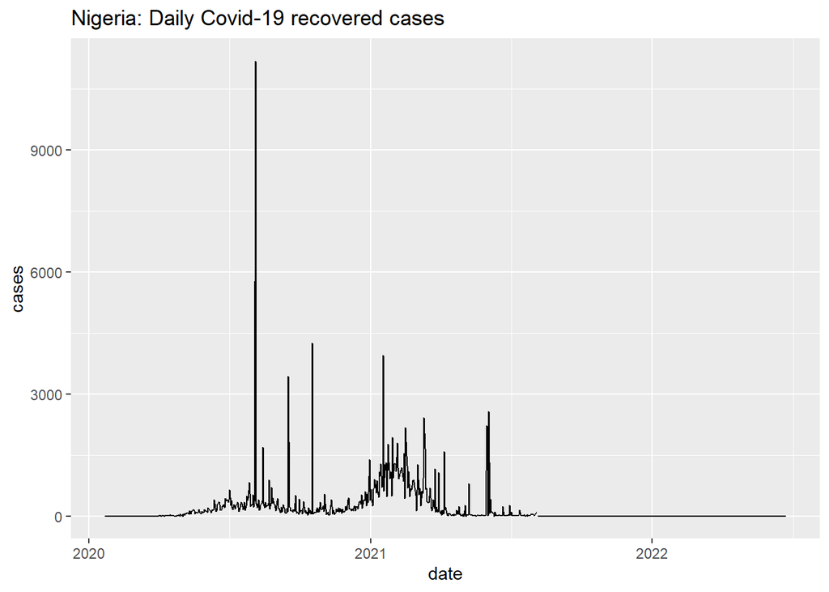

#### The highest number of recovery cases are recorded in 2020.Recoveries are significantly higher from second half of the year 2020 and it’s significantly lower after end of the first half of year 2021.

## Summary of the Death Cases

### Summary of the Death Cases in Nigeria

```
      date              province           country               lat
 Min.   :2020-01-22   Length:884         Length:884         Min.   :9.082
 1st Qu.:2020-08-29   Class :character   Class :character   1st Qu.:9.082
 Median :2021-04-07   Mode  :character   Mode  :character   Median :9.082
 Mean   :2021-04-07                                         Mean   :9.082
 3rd Qu.:2021-11-14                                         3rd Qu.:9.082
 Max.   :2022-06-23                                         Max.   :9.082

      long           type               cases            uid
 Min.   :8.675   Length:884         Min.   : 0.00   Min.   :566
 1st Qu.:8.675   Class :character   1st Qu.: 0.00   1st Qu.:566
 Median :8.675   Mode  :character   Median : 1.00   Median :566
 Mean   :8.675                      Mean   : 3.57   Mean   :566
 3rd Qu.:8.675                      3rd Qu.: 5.00   3rd Qu.:566
 Max.   :8.675                      Max.   :93.00   Max.   :566
                                    NA's   :2
     iso2               iso3               code3     combined_key
 Length:884         Length:884         Min.   :566   Length:884
 Class :character   Class :character   1st Qu.:566   Class :character
 Mode  :character   Mode  :character   Median :566   Mode  :character
                                       Mean   :566
                                       3rd Qu.:566
                                       Max.   :566

   population        continent_name     continent_code
 Min.   :206139587   Length:884         Length:884
 1st Qu.:206139587   Class :character   Class :character
 Median :206139587   Mode  :character   Mode  :character
 Mean   :206139587
 3rd Qu.:206139587
 Max.   :206139587
```

### Imputing missing values

```r
which(is.na(death_Nigeria_corona$cases))
```

```r
death_Nigeria_corona$cases[292] = mean(c(death_Nigeria_corona$cases[291],death_Nigeria_corona$cases[293]))
length(death_Nigeria_corona$cases)
```

```r
death_Nigeria_corona$col <- as.factor(c(rep("black", 290),rep("red", 2), rep("black", 884-292)))
summary(death_Nigeria_corona)
```

```
[1] 884
```

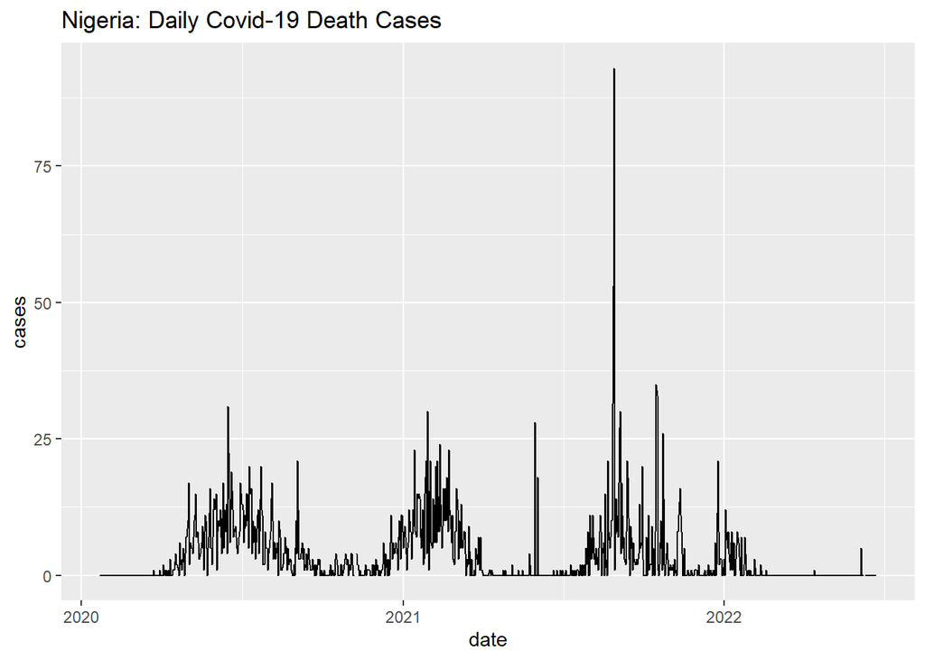

#### According to the above graph the shape of the distribution of death cases pretty much similarly to the distribution of confirmed cases data considering time period.The highest number of death cases reported in 2021 and it was 93.

## Daily Covid-19 Cases in Nigeria

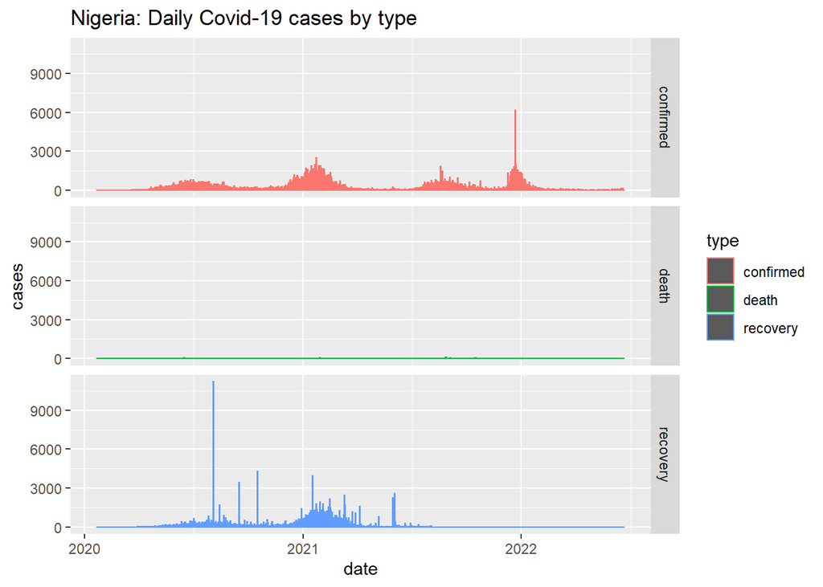

#### Above graph shows, the death cases are very lower than compared to confirmed cases.

## Cummilative line plot for total cases, total recoveries and total deaths

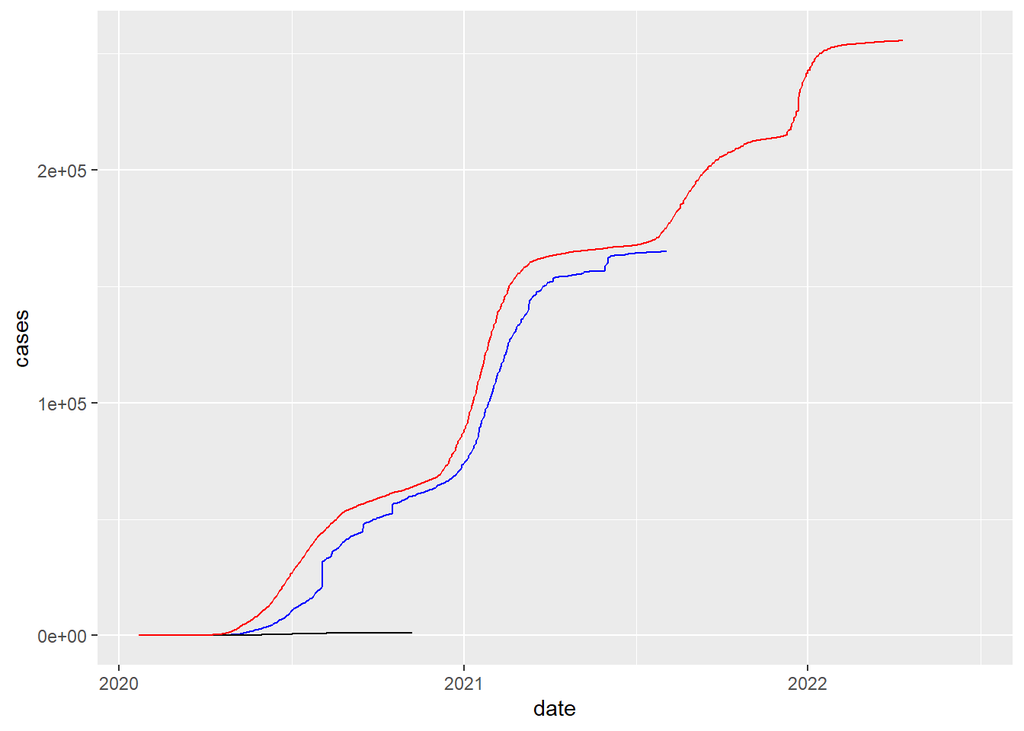

##### Recoveries = blue, Deaths = black, All Cases = red

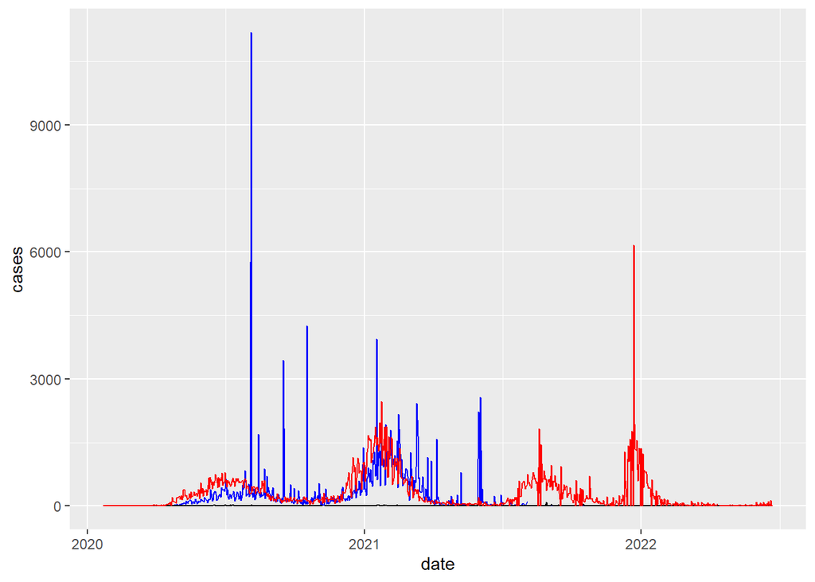

#### Above two graphs shows,the recovery cases higher than death cases in Nigeria.

## Comparison between neighbouring countries

#### Niger,Benin, Chad, Cameroon are some of the neighbouring countries to the Nigeria. Following graphs show, How variy confirmed,recovered,death cases between Nigeria and neighbouring countries.

### Confirmed cases among Nigeria & Neighbouring Countries

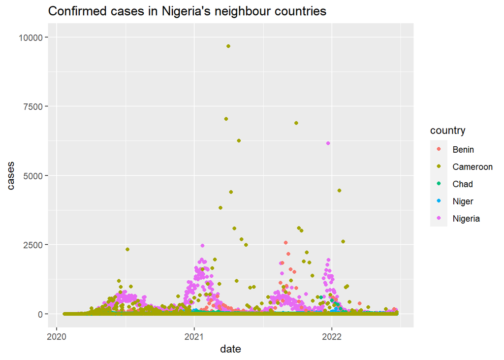

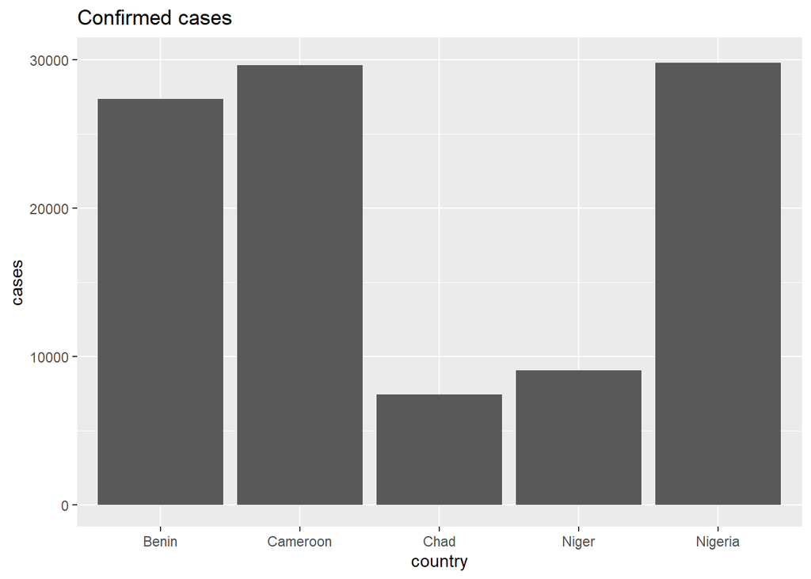

### Recovered cases among Nigeria & Neighbouring Countries

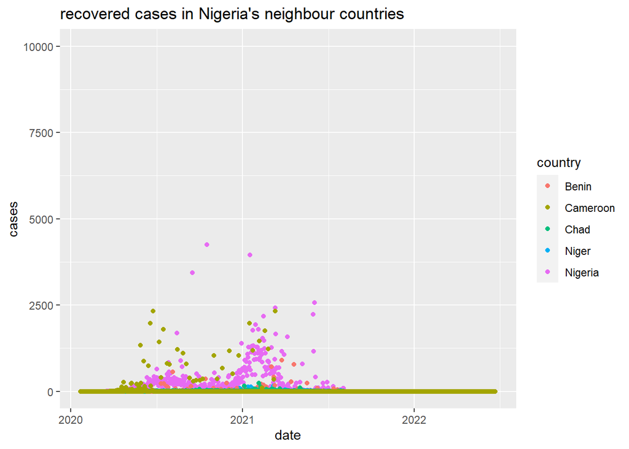

[figure not shown]

#### Both Camaroon and Nigeria have highest number of recoveries.It is mainly because of the high population in these contries compared to neighbor countries.

### Death cases among Nigeria & Neighbouring Countries

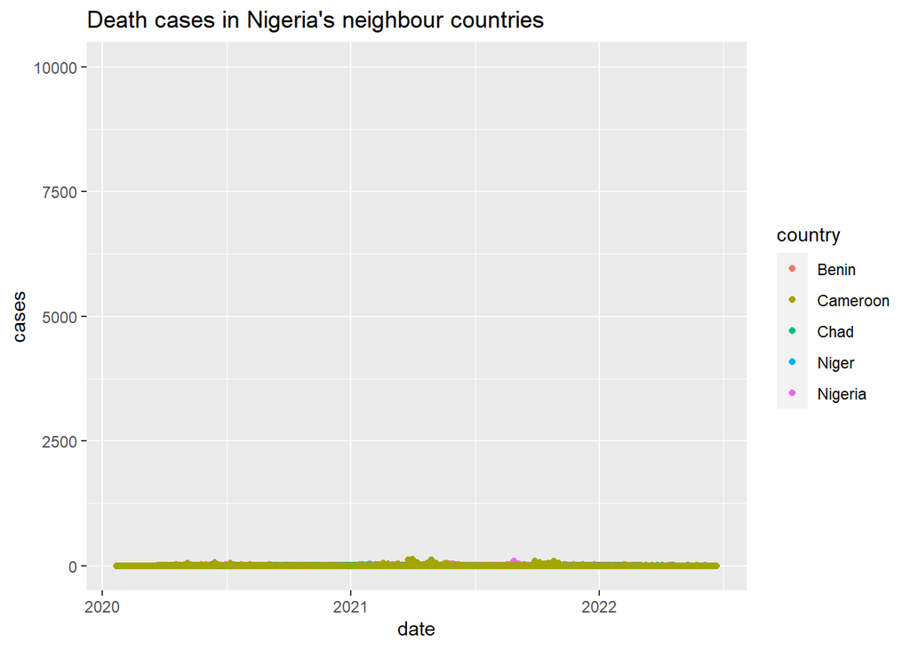

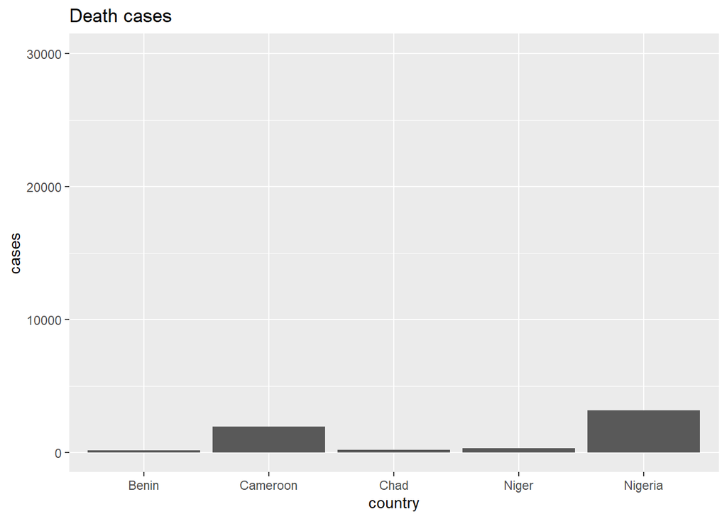

## **References**

- Falola, T. O. , Kirk-Greene, . Anthony Hamilton Millard , Udo, . Reuben Kenrick and Ajayi, . J.F. Ade (2022). Nigeria. Encyclopedia Britannica. https://www.britannica.com/place/Nigeria
- Timeline of the COVID-19 pandemic in Nigeria (2020). Wikipedia. https://en.m.wikipedia.org/wiki/COVID-19_pandemic_in_Nigeria